# egzaminas

Justina Sasnauskaite

2017 m sausis 20 d

```r
require(RCurl)
data1<-read.csv("https://raw.githubusercontent.com/1vbutkus/Econometrics1/master/Egzaminas/data.csv", skip= 7, sep=  ";" )
class(data1)
```

```
## [1] "data.frame"
```

```r
class(data1$amzius)
```

```
## [1] "factor"
```

```r
class(data1$galia)
```

```
## [1] "integer"
```

```r
class(data1$markesKodas)
```

```
## [1] "factor"
```

```r
class(data1$rida)
```

```
## [1] "numeric"
```

```r
class(data1$kaina)
```

```
## [1] "factor"
```

```r
kaina<-data1$kaina
kaina1<-as.numeric(as.character(kaina))
rida<-data1$rida
str(rida)
```

```
##  num [1:352] 164111 673467 494773 360468 601595 ...
```

cia viskas gerai su duomenu tipu

```r
amzius<-data1$amzius
amzius1<-as.numeric(as.character(amzius))
```

matosi visos NA

```r
galia<-data1$galia
markesKodas<-data1$markesKodas

data<-data.frame(kaina1,rida,amzius1,galia,markesKodas)
str(data)
```

```
## 'data.frame':    352 obs. of  5 variables:
##  $ kaina1     : num  12770 15181 17592 19854 5574 ...
##  $ rida       : num  164111 673467 494773 360468 601595 ...
##  $ amzius1    : num  11 12 15 2 NA 5 2 3 11 11 ...
##  $ galia      : int  55 55 75 65 55 65 65 45 55 65 ...
##  $ markesKodas: Factor w/ 3 levels "bm","ky","qt": 3 2 2 3 1 2 2 2 2 1 ...
```

dabar faktorius turim tik prie markeskodo

ieskom NA

```r
kurieNA<-is.na(data)
which(kurieNA, arr.ind=TRUE)
```

```
##      row col
## [1,]  54   1
## [2,]  97   1
## [3,] 100   1
## [4,]   5   3
## [5,] 131   3
## [6,] 201   3
```

minusuoju is duomenu visas sitas eilutes

```r
eilutes<-which(kurieNA, arr.ind=TRUE)[,1]
dataBeNa<-data[-eilutes,]
```

pasalinome

```r
length(eilutes)
```

```
## [1] 6
```

eiluciu, kadangi radom 6 NA.

Kintamuju apzvalga

```r
summary(dataBeNa)
```

```
##      kaina1           rida           amzius1          galia
##  Min.   : 4743   Min.   :154691   Min.   : 2.00   Min.   :45.00
##  1st Qu.: 8822   1st Qu.:357254   1st Qu.: 8.00   1st Qu.:55.00
##  Median :11741   Median :445282   Median :11.00   Median :55.00
##  Mean   :13686   Mean   :458146   Mean   :10.02   Mean   :59.02
##  3rd Qu.:18041   3rd Qu.:546894   3rd Qu.:13.00   3rd Qu.:65.00
##  Max.   :33518   Max.   :882829   Max.   :18.00   Max.   :75.00
##  markesKodas
##  bm:116
##  ky:118
##  qt:112
##
##
##
```

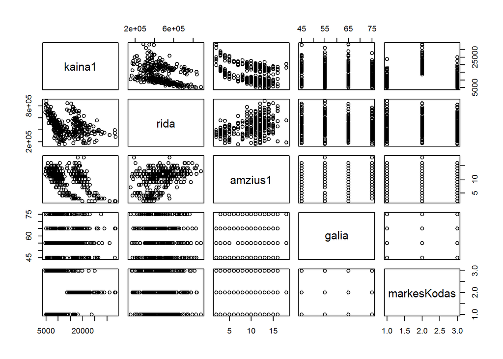

```r
plot(dataBeNa)
```

Tikrinu koreliacija,(istrinu markes koda nes jis yra fcator kintamasis)

```r
databemarkesKodo<-dataBeNa[,-5]
koreliacija<-sapply(databemarkesKodo,cor, y=databemarkesKodo$kaina)
koreliacija
```

```
##      kaina1        rida     amzius1       galia
##  1.00000000 -0.36858424 -0.51769540 -0.08995589
```

kadangi regresijos modeli taikysim kainai tai patikrinu tik kainos koreliacija su visais kitais stulpeliais

Dabar dataBeNa suskaidyti i testset ir trainset

trainset yra dide4snis masyvas ir ji sudarys 80 proc reiksmiu.

```r
fractionTrain<-0.8
fractionTest<-0.2
```

apskaiciuoju poaibiu dydzius

```r
sampleSizeTraining <- floor(fractionTrain   * nrow(dataBeNa))
sampleSizeTest  <- floor(fractionTest       * nrow(dataBeNa))
```

sukuriu atsitiktinius indeksus duomenims.

```r
indicesTraining    <- sort(sample(seq_len(nrow(dataBeNa)), size=sampleSizeTraining))
indicesTest  <- setdiff(seq_len(nrow(dataBeNa)), indicesTraining)
```

gauname duomenu dataBeNa du poaibius.

```r
trainset   <- dataBeNa[indicesTraining, ]
testset       <- dataBeNa[indicesTest, ]
```

sudarom modeli, kuriame kaina tiesiskai priklauso nuokitu kintamuju

```r
fit<-lm(kaina1~rida+amzius1+galia+markesKodas, data=trainset)
summary(fit)
```

```
##
## Call:
## lm(formula = kaina1 ~ rida + amzius1 + galia + markesKodas, data = trainset)
##
## Residuals:
##     Min      1Q  Median      3Q     Max
## -4581.7  -977.2  -126.6   777.3  8439.6
##
## Coefficients:
##                 Estimate Std. Error t value Pr(>|t|)
## (Intercept)    2.133e+04  6.871e+02  31.039   <2e-16 ***
## rida          -9.059e-03  7.205e-04 -12.574   <2e-16 ***
## amzius1       -6.498e+02  2.812e+01 -23.108   <2e-16 ***
## galia         -4.397e+00  9.294e+00  -0.473    0.637
## markesKodasky  9.698e+03  2.388e+02  40.610   <2e-16 ***
## markesKodasqt -2.409e+02  2.373e+02  -1.015    0.311
## ---
## Signif. codes:  0 '***' 0.001 '**' 0.01 '*' 0.05 '.' 0.1 ' ' 1
##
## Residual standard error: 1615 on 270 degrees of freedom
## Multiple R-squared:  0.9241, Adjusted R-squared:  0.9227
## F-statistic: 657.1 on 5 and 270 DF,  p-value: < 2.2e-16
```

paklaidu normalumo tikrinimui is pradziu pasiziuriu, kaip jos atrodo grafiskai.

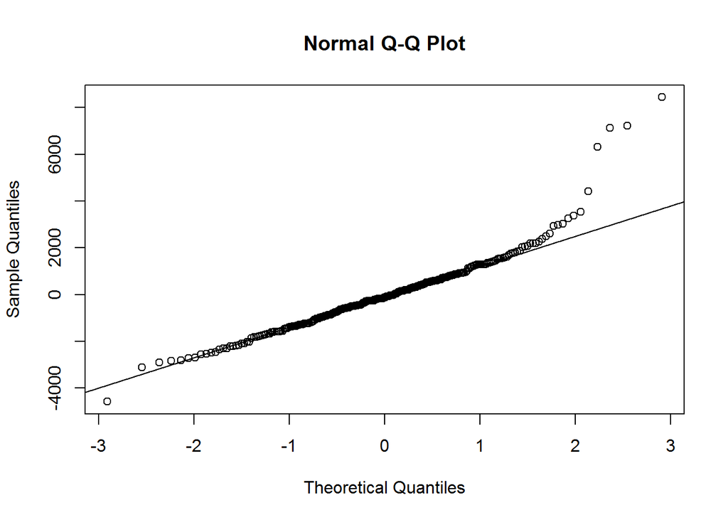

```r
residuals<-fit$residuals
qqnorm(residuals)
qqline(residuals)
```

Paklaidos gan normaliai pasiskirsciusios, taciau yra nukrypimu. Nuline hipoteze yra, kad paklaidos yra normalios.Patikriname hipoteze .

```r
shapiro.test(residuals(fit))
```

```
##
##  Shapiro-Wilk normality test
##
## data:  residuals(fit)
## W = 0.91747, p-value = 3.289e-11
```

testset prognozes:

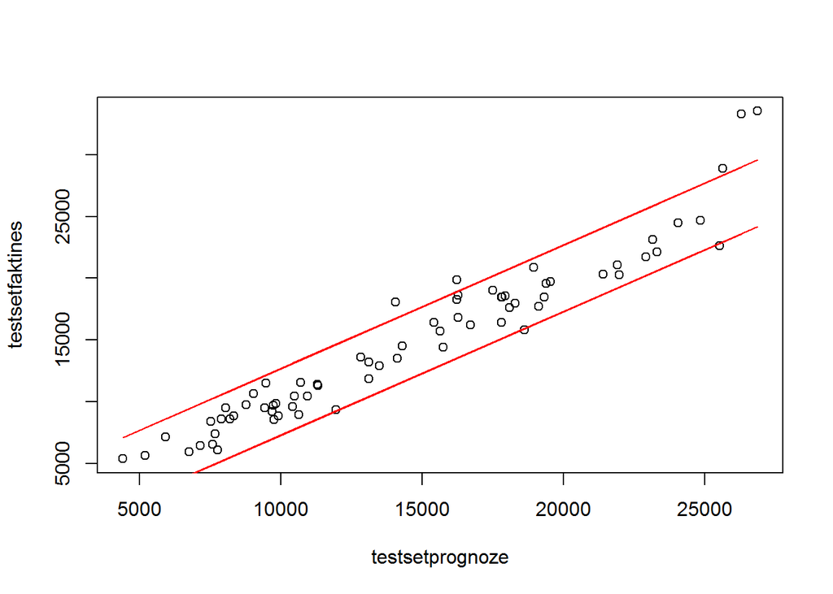

```r
testsetx<-data.frame(testset)
testsetprognoze<-predict(fit,newdata=testsetx)
testsetfaktines<-testset[,1]
plot(testsetprognoze,testsetfaktines)
confint<-predict(fit, testsetx, interval="predict",level=0.90)
lines(testsetprognoze, confint[,2], col=2)
lines(testsetprognoze, confint[,3], col=2)
```